# Supplementary materials

# 1. Load necessary materials

## 1.1. Load necessary libraries

```r
# Load libraries for data manipulation, analysis, and visualization

library(readr)       # For reading CSV files efficiently
library(dplyr)       # For data manipulation (filter, mutate, summarize, etc.)
library(tidyr)       # For tidying data (pivoting, reshaping)
library(ggplot2)     # For creating high-quality plots
library(lme4)        # For fitting linear mixed-effects models
library(emmeans)     # For computing estimated marginal means (post-hoc comparisons)
library(lmerTest)    # For hypothesis tests in linear mixed-effects models
library(gridExtra)   # For arranging multiple plots in a grid layout
library(cowplot)     # For complex ggplot2 layouts and annotations
library(DescTools)   # For descriptive statistics and other statistical tools
library(sjmisc)      # For data preparation and variable recoding
library(readxl)      # For reading Excel files
library(sjPlot)      # For creating summary tables and plots (especially for mixed models)
library(broom.mixed) # For tidying mixed-model outputs into data frames
library(ordinal)     # For ordinal regression models
library(ggridges)    # For ridgelines
```

## 1.2. Load project datasets

```r
# Set working directory to the project folder
setwd("/Users/jeremy-ua/Documents/Research/Projects/2025_Jens")

# Load CSV files into R and assign them to variables
# Each dataset is read using read_csv from the readr package

ai_prediction <- read_csv("ai_prediction.csv")       # Is it AI or not
funny_rating <- read_csv("funny_rating.csv")         # Human ratings of funniness
familiarity <- read_csv("familiarity.csv")           # Familiarity ratings
seen_before <- read_csv("seen_before.csv")           # Whether participants had seen items before
authors_gold_standard <- read_csv("authors_gold_standard.csv") # Gold standard labels
```

# 2. Prepare and reshape datasets

```r
# Add a 'subject' column as a unique identifier for each row
# Remove the first column (assumed to be an old index or redundant)
ai_prediction <- ai_prediction %>% mutate(subject = row_number()) %>% select(-1)
funny_rating  <- funny_rating %>% mutate(subject = row_number()) %>% select(-1)
familiarity   <- familiarity %>% mutate(subject = row_number()) %>% select(-1)
seen_before   <- seen_before %>% mutate(subject = row_number()) %>% select(-1)
authors_gold_standard <- authors_gold_standard %>% select(-1) # No subject needed

# 'pivot_longer' reshapes the data: each item becomes a row per subject
ai_long <- ai_prediction %>%
  pivot_longer(
    -subject,            # keep 'subject' column as is
    names_to = "item",    # column name for original variable names
    values_to = "ai_prediction"  # column name for values
  )

funny_long <- funny_rating %>%
  pivot_longer(
    -subject,
    names_to = "item",
    values_to = "funny_rating"
  )

familiarity_long <- familiarity %>%
  pivot_longer(
    -subject,
    names_to = "item",
    values_to = "familiarity"
  )

seen_before_long <- seen_before %>%
  pivot_longer(
    -subject,
    names_to = "item",
    values_to = "seen_before"
  )

authors_gold_standard_long <- pivot_longer(
  authors_gold_standard,
  cols = everything(),                    # pivot all columns
  names_to = "item",                      # column to hold original column names
  values_to = "authors_gold_standard"     # column to hold the values
)
```

# 3. Combine all datasets into a single long-format table

```r
# Merge all long-format datasets by 'subject' and 'item'
# Authors gold standard only by 'item' since it's the same for all subjects
data_long <- ai_long %>%
  left_join(funny_long, by = c("subject", "item")) %>%
  left_join(familiarity_long, by = c("subject", "item")) %>%
  left_join(seen_before_long, by = c("subject", "item")) %>%
  left_join(authors_gold_standard_long, by = "item") %>%
  mutate(
    # Convert relevant variables to factors for modeling
    ai_prediction = as.factor(ai_prediction),
    familiarity   = as.factor(familiarity),
    seen_before   = as.factor(seen_before),
    authors_gold_standard = as.factor(authors_gold_standard),

    # Ensure numeric variables are correctly typed
    funny_rating  = as.numeric(funny_rating),

    # Clean up 'item' names and convert to factor
    item          = as.factor(gsub("item", "", item)),

    # Convert subject ID to factor
    subject       = as.factor(subject)
  )
```

# 4. Relevel ordinal variables

```r
# Convert selected variables to ordered factors
# This is important for ordinal modeling and analyses
data_final <- data_long %>%
  mutate(
    seen_before  = as.ordered(seen_before),   # 'seen_before' is now an ordered factor
    funny_rating = as.ordered(funny_rating)   # 'funny_rating' is now an ordered factor
  )
```

#5. Statistical analysis

## Null model

```r
# Fit a null cumulative link mixed model (CLMM)
# This model includes only random intercepts for subject and item
# No fixed effects are included (intercept-only model)
m.null <- clmm(
  funny_rating ~ 1 + (1 | subject) + (1 | item),  # Formula for null model
  data = data_final
)

# Display model summary in the console (can be suppressed if needed)
summary(m.null)
```

```
Cumulative Link Mixed Model fitted with the Laplace approximation

formula: funny_rating ~ 1 + (1 | subject) + (1 | item)
data:    data_final
```

| link | threshold | nobs | logLik | AIC | niter | max.grad | cond.H |
| --- | --- | --- | --- | --- | --- | --- | --- |
| logit | flexible | 1280 | -1644.06 | 3300.12 | 346(1411) | 2.73e-05 | 9.9e+01 |

```
Random effects:
 Groups  Name        Variance Std.Dev.
 subject (Intercept) 2.4458   1.564
 item    (Intercept) 0.3375   0.581
Number of groups:  subject 64,  item 20

No Coefficients

Threshold coefficients:
    Estimate Std. Error z value
1|2  -1.1775     0.2468  -4.772
2|3   0.5119     0.2451   2.088
3|4   1.9924     0.2512   7.930
4|5   4.1007     0.2848  14.399
```

## Model 1: Main effect of AI prediction

```r
# Fit a CLMM including AI prediction as a fixed effect
m1.ai.pred <- clmm(
  funny_rating ~ ai_prediction + (1 | subject) + (1 | item),
  data = data_final
)

# Show summary with coefficients and random effects
summary(m1.ai.pred)
```

```
Cumulative Link Mixed Model fitted with the Laplace approximation

formula: funny_rating ~ ai_prediction + (1 | subject) + (1 | item)
data:    data_final
```

| link | threshold | nobs | logLik | AIC | niter | max.grad | cond.H |
| --- | --- | --- | --- | --- | --- | --- | --- |
| logit | flexible | 1280 | -1626.11 | 3266.22 | 427(1738) | 3.66e-04 | 1.1e+02 |

```
Random effects:
 Groups  Name        Variance Std.Dev.
 subject (Intercept) 2.4532   1.566
 item    (Intercept) 0.3387   0.582
Number of groups:  subject 64,  item 20

Coefficients:
                   Estimate Std. Error z value Pr(>|z|)
ai_predictionHuman   0.6962     0.1171   5.946 2.75e-09 ***
---
Signif. codes:  0 ‘***’ 0.001 ‘**’ 0.01 ‘*’ 0.05 ‘.’ 0.1 ‘ ’ 1

Threshold coefficients:
    Estimate Std. Error z value
1|2  -0.7921     0.2555  -3.100
2|3   0.9332     0.2561   3.644
3|4   2.4368     0.2637   9.241
4|5   4.5620     0.2975  15.335
```

```r
# Likelihood ratio test comparing null model to Model 1
print(anova(m.null, m1.ai.pred))
```

```
Likelihood ratio tests of cumulative link models:
```

|  | formula: | link: | threshold: |
| --- | --- | --- | --- |
| m.null | funny_rating ~ 1 + (1 \| subject) + (1 \| item) | logit | flexible |
| m1.ai.pred | funny_rating ~ ai_prediction + (1 \| subject) + (1 \| item) | logit | flexible |

```
           no.par    AIC  logLik LR.stat df Pr(>Chisq)
m.null          6 3300.1 -1644.1
m1.ai.pred      7 3266.2 -1626.1  35.906  1  2.071e-09 ***
---
Signif. codes:  0 ‘***’ 0.001 ‘**’ 0.01 ‘*’ 0.05 ‘.’ 0.1 ‘ ’ 1
```

## Model 2: Random slope of AI prediction by subject

```r
# Fit a CLMM with a random slope for AI prediction within subjects
# - This allows each subject to have their own effect of AI prediction
# - Items still have only random intercepts
m2.ai.pred <- clmm(
  funny_rating ~ ai_prediction + (1 + ai_prediction | subject) + (1 | item),
  data = data_final
)

# Show summary with coefficients, thresholds, and random effects
summary(m2.ai.pred)
```

```
Cumulative Link Mixed Model fitted with the Laplace approximation

formula:
funny_rating ~ ai_prediction + (1 + ai_prediction | subject) +
    (1 | item)
data:    data_final
```

| link | threshold | nobs | logLik | AIC | niter | max.grad | cond.H |
| --- | --- | --- | --- | --- | --- | --- | --- |
| logit | flexible | 1280 | -1624.13 | 3266.26 | 637(2583) | 2.01e-04 | 1.2e+02 |

```
Random effects:
 Groups  Name               Variance Std.Dev. Corr
 subject (Intercept)        3.0477   1.746
         ai_predictionHuman 0.1681   0.410    -0.712
 item    (Intercept)        0.3422   0.585
Number of groups:  subject 64,  item 20

Coefficients:
                   Estimate Std. Error z value Pr(>|z|)
ai_predictionHuman   0.7297     0.1307   5.584 2.35e-08 ***
---
Signif. codes:  0 ‘***’ 0.001 ‘**’ 0.01 ‘*’ 0.05 ‘.’ 0.1 ‘ ’ 1

Threshold coefficients:
    Estimate Std. Error z value
1|2  -0.7811     0.2749  -2.842
2|3   0.9591     0.2754   3.482
3|4   2.4650     0.2824   8.729
4|5   4.5892     0.3142  14.606
```

```r
# Likelihood ratio test: compare Model 1 (fixed effect only) vs. Model 2 (random slope)
anova(m1.ai.pred, m2.ai.pred)
```

```
Likelihood ratio tests of cumulative link models:
```

|  | formula: | link: | threshold: |
| --- | --- | --- | --- |
| m1.ai.pred | funny_rating ~ ai_prediction + (1 \| subject) + (1 \| item) | logit | flexible |
| m2.ai.pred | funny_rating ~ ai_prediction + (1 + ai_prediction \| subject) + (1 \| item) | logit | flexible |

```
           no.par    AIC  logLik LR.stat df Pr(>Chisq)
m1.ai.pred      7 3266.2 -1626.1
m2.ai.pred      9 3266.3 -1624.1  3.9619  2     0.1379
```

Result:

The likelihood ratio test shows no significant improvement when adding a random slope for AI prediction.

Therefore, Model 1 (main effect of AI prediction only) is preferred.

## Model 3: Main effect of gold standard

```r
# Fit a CLMM with AI prediction and authors' gold standard as fixed effects
m3.auth.std <- clmm(
  funny_rating ~ ai_prediction + authors_gold_standard +
    (1 | subject) + (1 | item),
  data = data_final
)

# Show summary of Model 3
summary(m3.auth.std)
```

```
Cumulative Link Mixed Model fitted with the Laplace approximation

formula:
funny_rating ~ ai_prediction + authors_gold_standard + (1 | subject) +
    (1 | item)
data:    data_final
```

| link | threshold | nobs | logLik | AIC | niter | max.grad | cond.H |
| --- | --- | --- | --- | --- | --- | --- | --- |
| logit | flexible | 1280 | -1625.83 | 3267.66 | 534(2169) | 3.77e-05 | 1.4e+02 |

```
Random effects:
 Groups  Name        Variance Std.Dev.
 subject (Intercept) 2.4527   1.5661
 item    (Intercept) 0.3277   0.5725
Number of groups:  subject 64,  item 20

Coefficients:
                           Estimate Std. Error z value Pr(>|z|)
ai_predictionHuman           0.6963     0.1171   5.947 2.73e-09 ***
authors_gold_standardhuman  -0.2094     0.2778  -0.754    0.451
---
Signif. codes:  0 ‘***’ 0.001 ‘**’ 0.01 ‘*’ 0.05 ‘.’ 0.1 ‘ ’ 1

Threshold coefficients:
    Estimate Std. Error z value
1|2  -0.8967     0.2900  -3.092
2|3   0.8284     0.2901   2.855
3|4   2.3321     0.2964   7.868
4|5   4.4575     0.3263  13.661
```

```r
# Likelihood ratio test: compare Model 1 vs. Model 3
anova(m1.ai.pred, m3.auth.std)
```

```
Likelihood ratio tests of cumulative link models:
```

|  | formula: | link: | threshold: |
| --- | --- | --- | --- |
| m1.ai.pred | funny_rating ~ ai_prediction + (1 \| subject) + (1 \| item) | logit | flexible |
| m3.auth.std | funny_rating ~ ai_prediction + authors_gold_standard + (1 \| subject) + (1 \| item) | logit | flexible |

```
            no.par    AIC  logLik LR.stat df Pr(>Chisq)
m1.ai.pred       7 3266.2 -1626.1
m3.auth.std      8 3267.7 -1625.8  0.5604  1     0.4541
```

Result:

Adding the gold standard as a fixed effect does not significantly improve model fit.

Model 1 (main effect of AI prediction only) remains the preferred model.

## Model 4: Main effect of familiarity

```r
# Fit a CLMM with AI prediction and familiarity as fixed effects
m4.fam <- clmm(
  funny_rating ~ ai_prediction + familiarity +
    (1 | subject) + (1 | item),
  data = data_final
)

# Show summary of Model 4
summary(m4.fam)
```

```
Cumulative Link Mixed Model fitted with the Laplace approximation

formula:
funny_rating ~ ai_prediction + familiarity + (1 | subject) +
    (1 | item)
data:    data_final
```

| link | threshold | nobs | logLik | AIC | niter | max.grad | cond.H |
| --- | --- | --- | --- | --- | --- | --- | --- |
| logit | flexible | 1280 | -1625.67 | 3267.33 | 519(2080) | 1.03e-03 | 1.2e+02 |

```
Random effects:
 Groups  Name        Variance Std.Dev.
 subject (Intercept) 2.4015   1.5497
 item    (Intercept) 0.3221   0.5676
Number of groups:  subject 64,  item 20

Coefficients:
                   Estimate Std. Error z value Pr(>|z|)
ai_predictionHuman   0.6966     0.1171   5.950 2.69e-09 ***
familiarityYes       0.1416     0.1504   0.942    0.346
---
Signif. codes:  0 ‘***’ 0.001 ‘**’ 0.01 ‘*’ 0.05 ‘.’ 0.1 ‘ ’ 1

Threshold coefficients:
    Estimate Std. Error z value
1|2  -0.7054     0.2685  -2.627
2|3   1.0198     0.2692   3.788
3|4   2.5219     0.2760   9.136
4|5   4.6429     0.3072  15.112
```

```r
# Likelihood ratio test: compare Model 1 (AI prediction only) vs. Model 4
anova(m1.ai.pred, m4.fam)
```

```
Likelihood ratio tests of cumulative link models:
```

|  | formula: | link: | threshold: |
| --- | --- | --- | --- |
| m1.ai.pred | funny_rating ~ ai_prediction + (1 \| subject) + (1 \| item) | logit | flexible |
| m4.fam | funny_rating ~ ai_prediction + familiarity + (1 \| subject) + (1 \| item) | logit | flexible |

```
           no.par    AIC  logLik LR.stat df Pr(>Chisq)
m1.ai.pred      7 3266.2 -1626.1
m4.fam          8 3267.3 -1625.7  0.8848  1     0.3469
```

Result:

Adding familiarity as a fixed effect does not significantly improve the model fit.

Model 1 (main effect of AI prediction only) remains the preferred model.

## Model 5: Main effect of “seen before”

```r
# Fit a CLMM with AI prediction and 'seen_before' as fixed effects
m5.seen <- clmm(
  funny_rating ~ ai_prediction + seen_before +
    (1 | subject) + (1 | item),
  data = data_final
)

# Show summary of Model 5
summary(m5.seen)
```

```
Cumulative Link Mixed Model fitted with the Laplace approximation

formula:
funny_rating ~ ai_prediction + seen_before + (1 | subject) +
    (1 | item)
data:    data_final
```

| link | threshold | nobs | logLik | AIC | niter | max.grad | cond.H |
| --- | --- | --- | --- | --- | --- | --- | --- |
| logit | flexible | 1280 | -1620.86 | 3259.72 | 737(3249) | 1.13e-03 | 1.2e+02 |

```
Random effects:
 Groups  Name        Variance Std.Dev.
 subject (Intercept) 2.4240   1.5569
 item    (Intercept) 0.3123   0.5588
Number of groups:  subject 64,  item 20

Coefficients:
                   Estimate Std. Error z value Pr(>|z|)
ai_predictionHuman  0.64770    0.11802   5.488 4.06e-08 ***
seen_before.L       0.60073    0.19158   3.136  0.00172 **
seen_before.Q       0.03167    0.19407   0.163  0.87038
---
Signif. codes:  0 ‘***’ 0.001 ‘**’ 0.01 ‘*’ 0.05 ‘.’ 0.1 ‘ ’ 1

Threshold coefficients:
    Estimate Std. Error z value
1|2  -1.1306     0.2751  -4.110
2|3   0.5974     0.2750   2.172
3|4   2.1100     0.2807   7.517
4|5   4.2596     0.3098  13.749
```

```r
# Likelihood ratio test: compare Model 1 (AI prediction only) vs. Model 5
anova(m1.ai.pred, m5.seen)
```

```
Likelihood ratio tests of cumulative link models:
```

|  | formula: | link: | threshold: |
| --- | --- | --- | --- |
| m1.ai.pred | funny_rating ~ ai_prediction + (1 \| subject) + (1 \| item) | logit | flexible |
| m5.seen | funny_rating ~ ai_prediction + seen_before + (1 \| subject) + (1 \| item) | logit | flexible |

```
           no.par    AIC  logLik LR.stat df Pr(>Chisq)
m1.ai.pred      7 3266.2 -1626.1
m5.seen         9 3259.7 -1620.9  10.503  2   0.005241 **
---
Signif. codes:  0 ‘***’ 0.001 ‘**’ 0.01 ‘*’ 0.05 ‘.’ 0.1 ‘ ’ 1
```

Result:

Adding seen_before as a fixed effect significantly improves the model fit compared to Model 1.

At this stage, Model 5 is preferred over previous models.

## Model 6: Random slope of “seen before” by subject

```r
# Fit a CLMM with AI prediction and 'seen_before' as fixed effects
# Add a random slope for 'seen_before' within subjects
m6.seen <- clmm(
  funny_rating ~ ai_prediction + seen_before +
    (1 + seen_before | subject) + (1 | item),
  data = data_final
)

# Show summary of Model 6
summary(m6.seen)
```

```
Cumulative Link Mixed Model fitted with the Laplace approximation

formula:
funny_rating ~ ai_prediction + seen_before + (1 + seen_before |
    subject) + (1 | item)
data:    data_final
```

| link | threshold | nobs | logLik | AIC | niter | max.grad | cond.H |
| --- | --- | --- | --- | --- | --- | --- | --- |
| logit | flexible | 1280 | -1619.30 | 3266.61 | 1149(5011) | 9.64e-04 | 1.5e+02 |

```
Random effects:
 Groups  Name          Variance Std.Dev. Corr
 subject (Intercept)   2.9681   1.7228
         seen_before.L 0.1394   0.3734    0.866
         seen_before.Q 0.2625   0.5123    0.025 -0.479
 item    (Intercept)   0.3253   0.5704
Number of groups:  subject 64,  item 20

Coefficients:
                   Estimate Std. Error z value Pr(>|z|)
ai_predictionHuman 0.649848   0.118693   5.475 4.37e-08 ***
seen_before.L      0.488294   0.232821   2.097    0.036 *
seen_before.Q      0.009627   0.254010   0.038    0.970
---
Signif. codes:  0 ‘***’ 0.001 ‘**’ 0.01 ‘*’ 0.05 ‘.’ 0.1 ‘ ’ 1

Threshold coefficients:
    Estimate Std. Error z value
1|2  -1.0909     0.3039  -3.589
2|3   0.6433     0.3039   2.117
3|4   2.1709     0.3100   7.004
4|5   4.3583     0.3404  12.805
```

```r
# Likelihood ratio test: compare Model 5 (fixed effect only) vs. Model 6 (random slope)
anova(m5.seen, m6.seen)
```

```
Likelihood ratio tests of cumulative link models:
```

|  | formula: | link: | threshold: |
| --- | --- | --- | --- |
| m5.seen | funny_rating ~ ai_prediction + seen_before + (1 \| subject) + (1 \| item) | logit | flexible |
| m6.seen | funny_rating ~ ai_prediction + seen_before + (1 + seen_before \| subject) + (1 \| item) | logit | flexible |

```
        no.par    AIC  logLik LR.stat df Pr(>Chisq)
m5.seen      9 3259.7 -1620.9
m6.seen     14 3266.6 -1619.3  3.1094  5     0.6831
```

Result:

Adding a random slope for seen_before by subject does not significantly improve model fit compared to Model 5.

Therefore, Model 5 (main effect of AI prediction + seen_before) remains the preferred model.

## Model 7: Interaction between AI prediction and “seen before”

```r
# Fit a CLMM with an interaction between AI prediction and 'seen_before'
m7.inter <- clmm(
  funny_rating ~ ai_prediction * seen_before +
    (1 | subject) + (1 | item),
  data = data_final
)

# Show summary of Model 7
summary(m7.inter)
```

```
Cumulative Link Mixed Model fitted with the Laplace approximation

formula:
funny_rating ~ ai_prediction * seen_before + (1 | subject) +
    (1 | item)
data:    data_final
```

| link | threshold | nobs | logLik | AIC | niter | max.grad | cond.H |
| --- | --- | --- | --- | --- | --- | --- | --- |
| logit | flexible | 1280 | -1619.47 | 3260.95 | 867(3546) | 1.70e-03 | 2.0e+02 |

```
Random effects:
 Groups  Name        Variance Std.Dev.
 subject (Intercept) 2.437    1.5610
 item    (Intercept) 0.312    0.5586
Number of groups:  subject 64,  item 20

Coefficients:
                                 Estimate Std. Error z value
ai_predictionHuman                 0.5755     0.2167   2.655
seen_before.L                      0.3927     0.3507   1.120
seen_before.Q                     -0.4654     0.3568  -1.304
ai_predictionHuman:seen_before.L   0.2479     0.3455   0.718
ai_predictionHuman:seen_before.Q   0.6688     0.4014   1.666
                                 Pr(>|z|)
ai_predictionHuman                0.00792 **
seen_before.L                     0.26280
seen_before.Q                     0.19213
ai_predictionHuman:seen_before.L  0.47297
ai_predictionHuman:seen_before.Q  0.09572 .
---
Signif. codes:  0 ‘***’ 0.001 ‘**’ 0.01 ‘*’ 0.05 ‘.’ 0.1 ‘ ’ 1

Threshold coefficients:
    Estimate Std. Error z value
1|2  -1.1733     0.3126  -3.754
2|3   0.5570     0.3122   1.784
3|4   2.0695     0.3175   6.518
4|5   4.2251     0.3440  12.281
```

```r
# Likelihood ratio test: compare Model 5 (main effects only) vs. Model 7 (interaction added)
anova(m5.seen, m7.inter)
```

```
Likelihood ratio tests of cumulative link models:
```

|  | formula: | link: | threshold: |
| --- | --- | --- | --- |
| m5.seen | funny_rating ~ ai_prediction + seen_before + (1 \| subject) + (1 \| item) | logit | flexible |
| m7.inter | funny_rating ~ ai_prediction * seen_before + (1 \| subject) + (1 \| item) | logit | flexible |

```
         no.par    AIC  logLik LR.stat df Pr(>Chisq)
m5.seen       9 3259.7 -1620.9
m7.inter     11 3260.9 -1619.5  2.7676  2     0.2506
```

Result:

Adding the interaction between AI prediction and seen_before does not significantly improve model fit.

Therefore, the simpler Model 5 (main effects only) remains the preferred model.

## Final Model

```r
final_model <- m5.seen
summary(final_model)
```

```
Cumulative Link Mixed Model fitted with the Laplace approximation

formula:
funny_rating ~ ai_prediction + seen_before + (1 | subject) +
    (1 | item)
data:    data_final
```

| link | threshold | nobs | logLik | AIC | niter | max.grad | cond.H |
| --- | --- | --- | --- | --- | --- | --- | --- |
| logit | flexible | 1280 | -1620.86 | 3259.72 | 737(3249) | 1.13e-03 | 1.2e+02 |

```
Random effects:
 Groups  Name        Variance Std.Dev.
 subject (Intercept) 2.4240   1.5569
 item    (Intercept) 0.3123   0.5588
Number of groups:  subject 64,  item 20

Coefficients:
                   Estimate Std. Error z value Pr(>|z|)
ai_predictionHuman  0.64770    0.11802   5.488 4.06e-08 ***
seen_before.L       0.60073    0.19158   3.136  0.00172 **
seen_before.Q       0.03167    0.19407   0.163  0.87038
---
Signif. codes:  0 ‘***’ 0.001 ‘**’ 0.01 ‘*’ 0.05 ‘.’ 0.1 ‘ ’ 1

Threshold coefficients:
    Estimate Std. Error z value
1|2  -1.1306     0.2751  -4.110
2|3   0.5974     0.2750   2.172
3|4   2.1100     0.2807   7.517
4|5   4.2596     0.3098  13.749
```

Main results:

- When roast judged as written by human, it is rated as sigingicantly more funny
- the more the participants is sure the to have seen the roast before, the more it is funny

# 6. Plot results

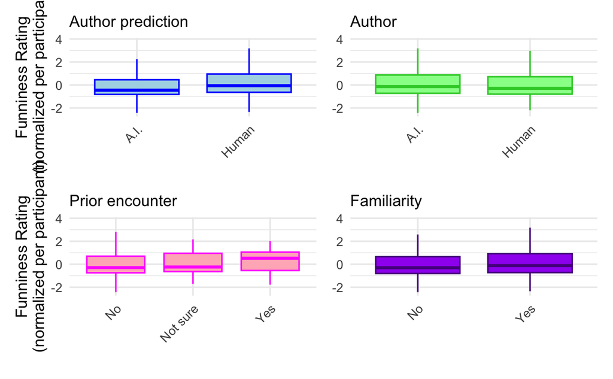

```r
library(patchwork)
data_scaled$authors_gold_standard <- as.character(data_scaled$authors_gold_standard)
data_scaled$authors_gold_standard[data_final$authors_gold_standard == "human"] <- "Human"
# Example: suppose your predictors are ai_prediction, human_prediction, and seen_before
# (replace or add more variables as needed)

p1 <- ggplot(data_scaled, aes(x = ai_prediction, y = as.numeric(funny_rating_scaled))) +
  geom_boxplot(trim = FALSE, fill = "lightblue", color = "blue", outlier.shape = NA) +
  labs(
    subtitle = "Author prediction",
    x = "",
    y = "Funniness Rating\n(normalized per participant)"
  ) +
  theme_minimal()
p2 <- ggplot(data_scaled, aes(x = authors_gold_standard, y = as.numeric(funny_rating_scaled))) +
  geom_boxplot(trim = FALSE, fill = "palegreen", color = "limegreen",outlier.shape = NA) +
  labs(
    subtitle = "Author",
    x="",
    y=""
  ) +
  theme_minimal()
p3 <- ggplot(data_scaled, aes(x = seen_before, y = as.numeric(funny_rating_scaled))) +
  geom_boxplot(trim = FALSE, fill = "lightpink", color = "magenta",outlier.shape = NA) +
  labs(
    subtitle = "Prior encounter",
    x="",
    y = "Funniness Rating\n(normalized per participant)"
  ) +
  theme_minimal()
p4 <- ggplot(data_scaled, aes(x = familiarity, y = as.numeric(funny_rating_scaled))) +
  geom_boxplot(trim = FALSE, fill = "purple", color = "purple4",outlier.shape = NA) +
  labs(
    subtitle = "Familiarity",
    x="",
    y=""
  ) +
  theme_minimal()
p1 <- p1 + theme(axis.text.x = element_text(angle = 45, hjust = 1))
p2 <- p2 + theme(axis.text.x = element_text(angle = 45, hjust = 1))
p3 <- p3 + theme(axis.text.x = element_text(angle = 45, hjust = 1))
p4 <- p4 + theme(axis.text.x = element_text(angle = 45, hjust = 1))

p2 <- p2 + ylab(NULL)
#p3 <- p3 + ylab(NULL)
p4 <- p4 + ylab(NULL)

# Combine them into one layout using patchwork
combined_plot <- (p1 | p2) / (p3 | p4) +
  plot_layout(guides = "collect")


combined_plot

# Save as a square image (e.g., 8x8 inches)
ggsave(
  filename = "combined_plot.png",   # change to your desired file name
  plot = combined_plot,             # your patchwork plot
  width = 4,                        # width in inches
  height = 6,                       # height in inches (same as width for square)
  dpi = 300                         # resolution
)
```